# 20분만에 끝내는 딥러닝

NLP 전이학습

[한국 R 사용자회](https://r2bit.com/)

# 1 NLP 패러다임 변화

[figure not shown]

# 2 자료구조

0과 1밖에 모르는 기계에게 인간의 언어 알려줘야 하는데, 이유는 컴퓨터는 숫자만 인식할 수 있기 때문에 바이너리 코드로 처리해 줘야한다. 텍스트 데이터 즉, 순서가 없는 범주형 데이터를 수치형 데이터로 변환한다. 벡터에서 해당되는 하나의 데이터만 1로 변경해 주고 나머지는 0으로 채워주는 방식으로 원핫 인코딩(One-Hot Encoding), 통계학에서 가변수(Dummy Variable)처리라고 부른다.

**TF(단어 빈도, term frequency)**는 특정한 단어가 문서 내에 얼마나 자주 등장하는지를 나타내는 값으로 이 값이 높을수록 문서에서 중요하다고 생각할 수 있지만, 단어 자체가 문서군 내에서 자주 사용되는 경우,이것은 그 단어가 흔하게 등장한다는 것을 의미도 된다.

이것을 **DF(문서 빈도, document frequency)**라고 하며, 이 값의 역수를 **IDF(역문서 빈도, inverse document frequency)**라고함 **TF-IDF**는 TF와 IDF를 곱한 값이 된다.

단어문서행렬(Term Document Matrix)을 전치(Transpose)하게 되면 문서단어행렬(DTM)이 된다. 단어문서행렬은 다음과 같은 형태를 갖는다.

|  | $문서_1$ | $문서_1$ | $문서_1$ | $\cdots$ | $문서_n$ |
| --- | --- | --- | --- | --- | --- |
| $단어_1$ | 0 | 0 | 0 | 0 | 0 |
| $단어_2$ | 1 | 1 | 0 | 0 | 0 |
| $단어_3$ | 1 | 0 | 0 | 0 | 0 |
| $\cdots$ | 0 | 0 | 2 | 1 | 1 |
| $단어_m$ | 0 | 0 | 0 | 1 | 0 |

문서단어행렬은 단서문서행렬을 전치하여 다음과 같은 형태를 갖는다.

|  | $단어_1$ | $단어_1$ | $단어_1$ | $\cdots$ | $단어_n$ |
| --- | --- | --- | --- | --- | --- |
| $문서_1$ | 0 | 1 | 1 | 0 | 0 |
| $문서_2$ | 0 | 1 | 0 | 0 | 0 |
| $문서_3$ | 0 | 0 | 0 | 2 | 0 |
| $\cdots$ | 0 | 0 | 0 | 1 | 1 |
| $문서_m$ | 0 | 0 | 0 | 1 | 0 |

딥러닝 학습 후 n-차원으로 워드임베딩하면 다음과 같은 형태를 갖는다.

|  | $차원_1$ | $차원_1$ | $차원_1$ | $\cdots$ | $차원_n$ |
| --- | --- | --- | --- | --- | --- |
| $단어_1$ | 0.754 | 0.625 | 0.525 | 0.954 | 0.685 |
| $단어_2$ | 1 | 1 | 0.219 | 0.791 | 0.652 |
| $단어_3$ | 0.125 | 0.968 | 0.215 | 0.571 | 0.845 |
| $\cdots$ | 0.857 | 0.323 | 0.125 | 0.847 | 0.696 |
| $단어_m$ | 0.214 | 0.841 | 0.985 | 1 | 0.198 |

# 3 NLP 기술 역사

[figure not shown]

# 4 워드 임베딩

- [`glove`](https://nlp.stanford.edu/projects/glove/)
  - [`textdata`](https://cran.r-project.org/web/packages/textdata/index.html)
  - [`word2vec`](https://github.com/bnosac/word2vec)
- [`fastText`](https://github.com/facebookresearch/fastText)
  - [`fastText`](https://cran.r-project.org/web/packages/fastText/index.html)

`word2vec`은 Autoencoder 와 유사하나 몇가지 점에서 차이점이 있다. 즉, `word2vec`의 목표는 단어를 컴퓨터가 계산 가능한 형태로 One-hot 인코딩(통계학에서 더미 변수 인코딩)하게 되면 매우 성긴 행렬로 표현되기 때문에 이런 문제를 해결하고자 단어 인근 정보를 유지한 상태의 행렬정보로 새롭게 매핑한 것이다.

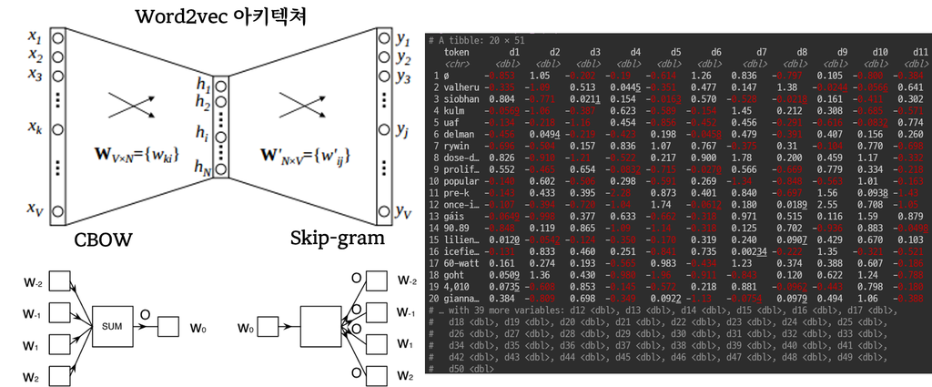

## 4.1 단어(코사인) 유사도

```r
library(tidytext)
library(textdata)
library(tidyverse)
library(widyr)

glove6b <- embedding_glove6b(dimensions = 50)

tidy_glove <- glove6b %>%
  pivot_longer(contains("d"),
               names_to = "dimension") %>%
  rename(item1 = token)

tidy_glove
```

```
# A tibble: 20,000,000 × 3
   item1 dimension     value
   <chr> <chr>         <dbl>
 1 the   d1         0.418
 2 the   d2         0.250
 3 the   d3        -0.412
 4 the   d4         0.122
 5 the   d5         0.345
 6 the   d6        -0.0445
 7 the   d7        -0.497
 8 the   d8        -0.179
 9 the   d9        -0.000660
10 the   d10       -0.657
# … with 19,999,990 more rows
```

```r
cosine_sim_fn <- function(word1 = "man", word2 = "woman") {

  # 첫번째 단어 벡터
  u <- tidy_glove %>%
  filter(item1 == word1) %>%
  pull(value)

  # 두번째 단어 벡터
  v <- tidy_glove %>%
    filter(item1 == word2) %>%
    pull(value)

  # 코사인 유사도 계산
  num <- sum(u * v)
  norm_u <- InspectChangepoint:::vector.norm(u)
  norm_v <- InspectChangepoint:::vector.norm(v)
  denum <- norm_u * norm_v
  cos_sim <- num/denum

  return(cos_sim)
}

cosine_sim_fn("man", "woman")
```

```
[1] 0.8860338
```

단어 유사도 시각화

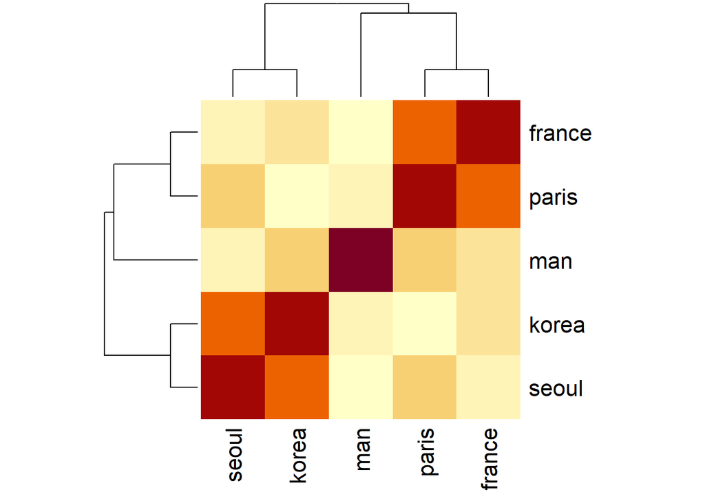

```r
tidy_glove %>%
  filter(item1 %in% c("korea", "france", "seoul", "paris", "man", "qeen")) %>%
  pivot_wider(names_from = item1, values_from = value) %>%
  select(-dimension) %>%
  as.matrix() %>%
  lsa::cosine() %>%
  heatmap()
```

## 4.2 인접 단어

```r
nearest_neighbors <- function(df, token) {
  df %>%
    widely(
      ~ {
        y <- .[rep(token, nrow(.)), ]
        res <- rowSums(. * y) /
          (sqrt(rowSums(. ^ 2)) * sqrt(sum(.[token, ] ^ 2)))
        matrix(res, ncol = 1, dimnames = list(x = names(res)))
      },
      sort = TRUE,
      maximum_size = NULL
    )(item1, dimension, value) %>%
    select(-item2)
}

nearest_neighbors(tidy_glove, "korea")
```

```
# A tibble: 400,000 × 2
   item1     value
   <chr>     <dbl>
 1 korea     1
 2 korean    0.878
 3 pyongyang 0.851
 4 dprk      0.842
 5 seoul     0.824
 6 china     0.823
 7 japan     0.815
 8 iran      0.807
 9 beijing   0.773
10 taiwan    0.765
# … with 399,990 more rows
```

```r
library(umap)

glove6b_sample <- glove6b %>%
  sample_n(size = 100)

glove_umap <-  umap(glove6b_sample %>% select(-token))

umap_df <- glove_umap$layout %>%
  as.data.frame()%>%
  rename(UMAP1="V1",
         UMAP2="V2") %>%
  bind_cols(glove6b_sample) %>%
  select(token, everything()) %>%
  as_tibble()

umap_df %>%
  ggplot(aes(x = UMAP1,
             y = UMAP2))+
  geom_point()+
  labs(x = "UMAP1",
       y = "UMAP2",
      subtitle = "UMAP plot") +
  ggrepel::geom_text_repel(aes(label = token))
```

[output not shown]

```r
king_v <- tidy_glove %>%
  filter(item1 == "king") %>%
  rename(king = item1,
         king_v = value)

man_v <- tidy_glove %>%
  filter(item1 == "man") %>%
  rename(man = item1,
         man_v = value)

woman_v <- tidy_glove %>%
  filter(item1 == "woman") %>%
  rename(woman = item1,
         woman_v = value)

queen_v <- tidy_glove %>%
  filter(item1 == "queen") %>%
  rename(queen = item1,
         queen_v = value)

question_v <- king_v %>%
  left_join(man_v) %>%
  left_join(woman_v) %>%
  left_join(queen_v) %>%
  mutate(value = king_v - man_v + woman_v) %>%
  mutate(item1 = "king-man+woman") %>%
  select(item1, dimension, value)

infer_glove <- tidy_glove  %>%
  bind_rows(question_v)

nearest_neighbors(infer_glove, "king-man+woman")
```

```
# A tibble: 400,001 × 2
   item1          value
   <chr>          <dbl>
 1 king-man+woman 1
 2 king           0.886
 3 queen          0.861
 4 daughter       0.768
 5 prince         0.764
 6 throne         0.763
 7 princess       0.751
 8 elizabeth      0.751
 9 father         0.731
10 kingdom        0.730
# … with 399,991 more rows
```

# 5 RNN/LSTM, Attention, Transformer

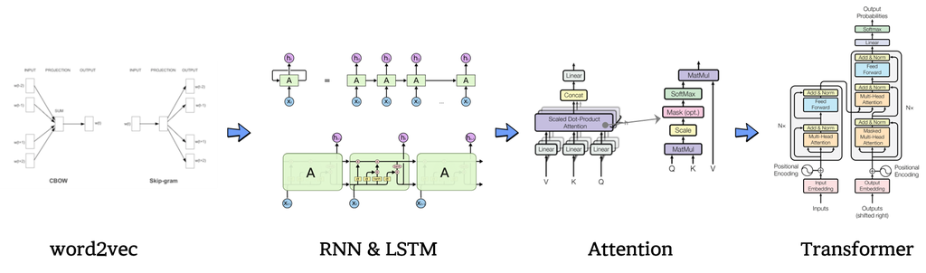

# 6 언어 모델

> You shall know a word by the company it keeps  
> Firth, J. R.

[figure not shown]

The Rise of Cognitive AI, https://towardsdatascience.com/the-rise-of-cognitive-ai-a29d2b724ccc

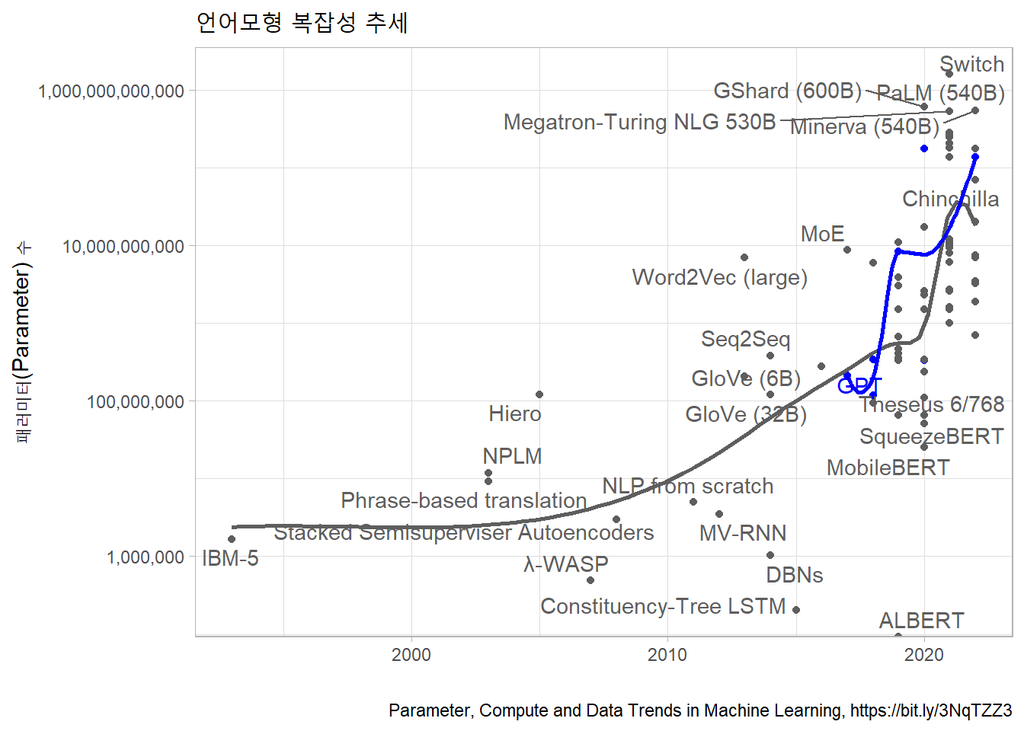

```r
library(googlesheets4)
library(tidyverse)
library(patchwork)

# googlesheets4::gs4_deauth()
# googlesheets4::gs4_auth()

lang_raw <- read_sheet("https://docs.google.com/spreadsheets/d/1AAIebjNsnJj_uKALHbXNfn3_YsT6sHXtCU0q7OIPuc4/")

lang_tbl <- lang_raw %>%
  janitor::clean_names() %>%
  filter(! is.na(system),
         ! is.na(parameters)) %>%
  select(system, domain, year, parameters) %>%
  filter(domain == "Language") %>%
  group_by(system, year) %>%
  summarise(parameters = max(parameters)) %>%
  mutate(imp_model = case_when( system == "GPT" ~ TRUE,
                                system == "Transformer" ~ TRUE,
                                system == "BERT-Large" ~ TRUE,
                                system == "Megatron-LM" ~ TRUE,
                                system == "ELECTRA" ~ TRUE,
                                system == "GPT-3 175B" ~ TRUE,
                                system == "LaMDA" ~ TRUE,
                                TRUE ~ FALSE))





lang_whole_gg <- lang_tbl %>%
  ggplot(aes(x = year, y = parameters, color = imp_model)) +
    geom_point() +
    scale_y_log10(labels = scales::comma) +
    ggrepel::geom_text_repel(aes(label = system)) +
    geom_smooth(se = FALSE) +
    theme_light() +
    labs(title = "언어모형 복잡성 추세",
         x = "",
         y = "패러미터(Parameter) 수",
         caption = "Parameter, Compute and Data Trends in Machine Learning, https://bit.ly/3NqTZZ3") +
    scale_color_manual(values = c("gray37", "blue"))  +
    theme(legend.position = "none")

lang_latest_gg <- lang_tbl %>%
  filter(year > 2015) %>%
  ggplot(aes(x = year, y = parameters, color = imp_model)) +
    geom_point() +
    scale_y_log10(labels = scales::comma) +
    ggrepel::geom_text_repel(aes(label = system)) +
    theme_light() +
    labs(x = "",
         y = "") +
     theme(axis.ticks.y = element_blank(),
           axis.text.y = element_blank(),
           legend.position = "none") +
     scale_color_manual(values = c("gray37", "blue"))

lang_whole_gg
```

```r
# lang_whole_gg +
#   inset_element(lang_latest_gg, 0.15, 0.5, 0.6, 0.95, align_to = 'full')
```